# gcTMB

2026-11-12

The package gcTMB fits growth curves over time using the Template Model Builder (TMB) framework. The curves can depend on covariates, have random effects (e.g. for repeated measurements of the same individuals), and the response can follow a range of distributions.

## Growth models

All models but the linear one are of the form $f(t) = b_1 F(z(t))$, with a function $F$ increasing from 0 to 1 and a transformed time $z(t)$, increasing in $t$:

- $b_1$ is the asymptote, the response approached at late times,
- $b_2$ is the time of the maximum growth rate, the inflection point of the curve (logistic, Gompertz, Weibull, normal, gamma), or the time of half the asymptote (Hill),
- $b_3$ is the scale of the curve on the time axis (logistic, Gompertz, normal), positive for an increasing curve, its slope on the log time axis (Hill), or its shape (Weibull, gamma).

The parameter $b_4$ is the threshold of truncated curves, and $b_5$ the asymmetry of the curve (both below).

#### logistic

$$f(t) = \frac{b_1}{1 +
\exp\left(-\frac{t - b_2}{b_3}\right)}$$

The curve is symmetric around $b_2$, where it reaches half of its asymptote and grows fastest.

#### gompertz

$$f(t) = b_1
\exp\left(-\exp\left(-\frac{t - b_2}{b_3}\right)\right)$$

The curve reaches $\mathrm{e}^{-1} \approx 37\%$ of its asymptote at $b_2$, and approaches the asymptote more slowly than it leaves zero. The maximum growth rate is $b_1 / (\mathrm{e}^1 b_3)$.

#### hill

$$f(t) = \frac{b_1}{1 + (b_2 / t)^{b_3}}$$

A logistic curve on the log time axis, $z = b_3 (\log t - \log b_2)$, for positive times; it reaches half of its asymptote at $b_2$.

#### weibull

$$f(t) = b_1 \left(1 -
\exp\left(-\frac{b_3 - 1}{b_3}
\left(\frac{t}{b_2}\right)^{b_3}\right)\right)$$

For positive times, with the shape $b_3 > 1$; parameterised so that $b_2$ is the inflection point, the time of the maximum growth rate.

#### normal

$$f(t) = b_1 \Phi\left(\frac{t -
b_2}{b_3}\right)$$

with the standard normal distribution function $\Phi$. The curve is symmetric around $b_2$, where it reaches half of its asymptote and grows fastest; $b_3$ is the standard deviation of the times of growth.

#### gamma

$$f(t) = b_1 P\left(b_3, \frac{(b_3 -
1)\, t}{b_2}\right)$$

with the regularised lower incomplete gamma function $P$, the distribution function of the gamma distribution with shape $b_3 > 1$ and scale $b_2/(b_3 - 1)$. For positive times; parameterised so that $b_2$, the mode of the gamma density, is the inflection point. The curve approaches the asymptote more slowly than it leaves zero, the more so for a small shape $b_3$, and tends to the normal curve for a large shape.

#### linear

$$f(t) = b_1 t + b_2$$

A straight line with slope $b_1$ and intercept $b_2$, for comparison with the growth curves. It has no asymptote, does not use $b_3$ to $b_5$, and is not truncated. `timeto()` gives the times at which it reaches given responses (`type = "absolute"`), and `maxrate()` its constant growth rate $b_1$.

#### Truncation at a threshold

By default, $F$ is truncated at a threshold time $b_4$, as a distribution function truncated from below:

$$f(t) = b_1 \frac{F(z(t)) - F(z(b_4))}{1
- F(z(b_4))} \quad \text{for } t > b_4,$$

and $f(t) = 0$ up to $b_4$, e.g. before the emergence of the plants or the first pods. $b_2$ and $b_3$ keep their meaning for the curve without truncation. By default $b_4$ is fixed at 0, so that the curve starts at zero at $t = 0$, e.g. at sowing; `fix = c(b4 = FALSE)` estimates it, and `truncated = FALSE` gives the curves without truncation. The Hill and Weibull curves are zero up to $t = 0$ anyway, so a threshold at or below 0 does not change them.

#### Maximum growth rate and inflection point

For the curves with the default threshold $b_4 = 0$ and without asymmetry ($b_5 = 1$), the inflection point $t_m$, the fraction $G_m = f(t_m)/b_1$ of the asymptote reached there, and the maximum growth rate $r_{\max}$, the slope of the curve at $t_m$, follow from those of the curves without truncation:

| Model | Inflection point $t_m$ | Fraction $G_m^0$ | Maximum growth rate $r_{\max}^0$ | $p_0 = F(z(0))$ |
| --- | --- | --- | --- | --- |
| logistic | $b_2$ | $1/2$ | $\dfrac{b_1}{4 b_3}$ | $\dfrac{1}{1 + \mathrm{e}^{b_2/b_3}}$ |
| gompertz | $b_2$ | $\mathrm{e}^{-1} \approx 0.37$ | $\dfrac{b_1}{\mathrm{e}^1 b_3}$ | $\exp\left(-\mathrm{e}^{b_2/b_3}\right)$ |
| hill | $b_2 \left(\dfrac{b_3 - 1}{b_3 + 1}\right)^{1/b_3}$ | $\dfrac{b_3 - 1}{2 b_3}$ | $\dfrac{b_1}{b_2} \dfrac{(b_3 - 1)^{1 - 1/b_3} (b_3 + 1)^{1 + 1/b_3}}{4 b_3}$ | 0 |
| weibull | $b_2$ | $1 - \mathrm{e}^{-(b_3 - 1)/b_3}$ | $\dfrac{b_1}{b_2} (b_3 - 1) \mathrm{e}^{-(b_3 - 1)/b_3}$ | 0 |
| normal | $b_2$ | $1/2$ | $\dfrac{b_1}{\sqrt{2\pi}\, b_3}$ | $\Phi\left(-\dfrac{b_2}{b_3}\right)$ |
| gamma | $b_2$ | $P(b_3, b_3 - 1)$ | $\dfrac{b_1}{b_2} \dfrac{(b_3 - 1)^{b_3} \mathrm{e}^{-(b_3 - 1)}}{\Gamma(b_3)}$ | 0 |
| linear | none | none | $b_1$ at all times | none |

Here $G_m^0$ and $r_{\max}^0$ are for the curves without truncation, and $p_0$ is the fraction of the asymptote these reach at $t = 0$. The truncation at $b_4 = 0$ scales the curve by $1/(1 - p_0)$ after $t = 0$, so for $b_2 > 0$ the inflection point stays at $t_m$, and

$$G_m = \frac{G_m^0 - p_0}{1 - p_0},
\qquad r_{\max} = \frac{r_{\max}^0}{1 - p_0}.$$

For the Hill, Weibull and gamma curves, $p_0 = 0$ and nothing changes. $G_m$ tells how much of the growth has occurred when the growth is fastest. The Hill curve has an inflection point at a positive time only for $b_3 > 1$. `maxrate()` computes $t_m$, $r_{\max}$ and $G_m$ for all curves, also with an estimated threshold and asymmetric ones.

#### Asymmetry

Each model has an asymmetry parameter $b_5 > 0$, with $b_5 = 1$ the curves above. By default $b_5$ is fixed at 1; `fix = c(b5 = FALSE)` estimates it, and the log link, `link = c(b5 = "log")`, keeps it positive. The truncation applies to the asymmetric curves in the same way.

- logistic, the Richards curve:
  $$f(t) =
  \frac{b_1}{\left(1 + b_5 \exp\left(-\frac{t -
  b_2}{b_3}\right)\right)^{1/b_5}}$$
  which tends to the Gompertz curve as $b_5 \to 0$;
- gompertz, a power of the survival function $1 - F$:
  $$f(t)
  = b_1 \left(1 - \left(1 - \exp\left(-\exp\left(-\frac{t -
  b_2}{b_3}\right)\right)\right)^{b_5}\right)$$
  as a power of the Gompertz $F$ itself would only shift the curve in time;
- hill, the five-parameter log-logistic curve:
  $$f(t) = \frac{b_1}{\left(1 + (b_2 /
  t)^{b_3}\right)^{b_5}}$$
- weibull, the exponentiated Weibull curve:
  $$f(t) = b_1 \left(1 - \exp\left(-\frac{b_3 -
  1}{b_3} \left(\frac{t}{b_2}\right)^{b_3}\right)\right)^{b_5}$$
- normal and gamma, a power of their distribution function: $f(t) = b_1 F(z(t))^{b_5}$.

For the Richards curve, $b_2$ remains the inflection point for all $b_5$: $t_m = b_2$, where the curve reaches the fraction $G_m = (1 + b_5)^{-1/b_5}$ of its asymptote, with the maximum growth rate $r_{\max} = \dfrac{b_1}{b_3} (1 + b_5)^{-(1 + b_5)/b_5}$. $G_m$ goes from $\mathrm{e}^{-1}$ (Gompertz, $b_5 \to 0$) through $1/2$ (logistic, $b_5 = 1$) towards 1 as $b_5$ grows. For the other models with $b_5 \neq 1$, $b_2$ is the location of the curve rather than its inflection point or the time of half the asymptote.

## The faba bean data

The data set `FabaHeights25` contains the heights of 25 faba bean plants, five at each of five treatment levels, measured on eight days between 14 and 61 days after sowing (`DAS`).

```r
library(gcTMB)
library(ggplot2)
head(FabaHeights25)
```

```
#>   Tube_ID Treatment       Date DAS height DASfact plant_ID
#> 1       6       0.8 2025-09-24  14     19      14        6
#> 2       7       0.8 2025-09-24  14     18      14        7
#> 3       8       0.8 2025-09-24  14     18      14        8
#> 4       9       0.8 2025-09-24  14     16      14        9
#> 5      10       0.8 2025-09-24  14     17      14       10
#> 6      11       0.6 2025-09-24  14     17      14       11
```

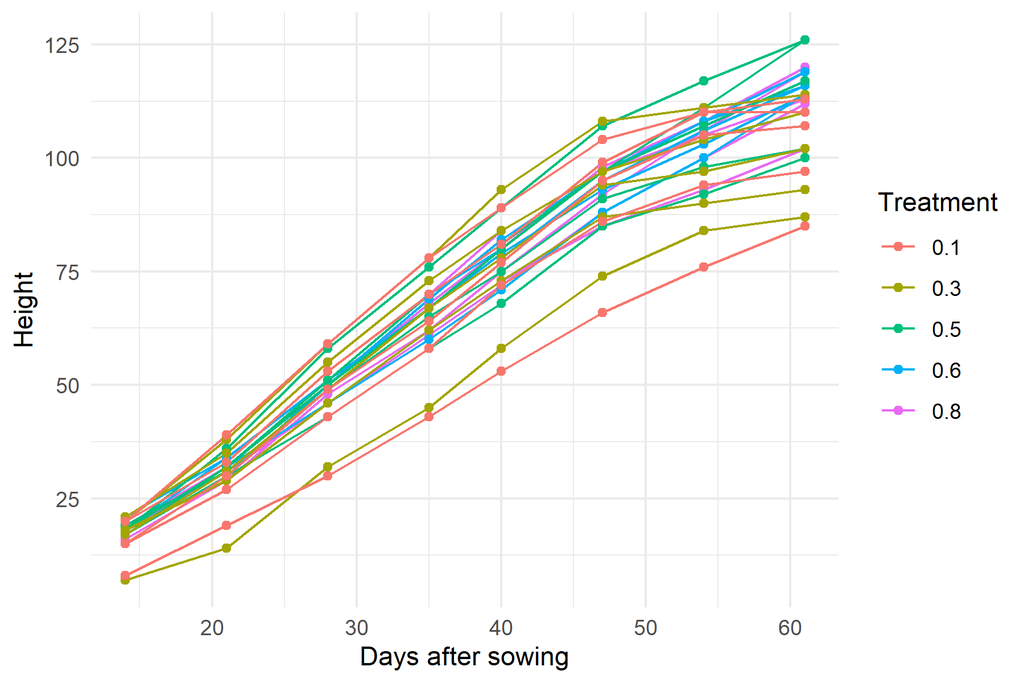

```r
ggplot(FabaHeights25, aes(x = DAS, y = height, group = plant_ID, colour = factor(Treatment))) +
  geom_line() +
  geom_point() +
  labs(x = "Days after sowing", y = "Height", colour = "Treatment") +
  theme_minimal()
```

## Fitting a growth curve

The main function is `gcTMB()`, with the response and the time in the formula, and the growth model in `model`.

```r
fit <- gcTMB(height ~ DAS, data = FabaHeights25, model = "logistic")
summary(fit)
```

```
#> Call:
#> gcTMB(form = height ~ DAS, data = FabaHeights25, model = "logistic")
#>
#> Model:  logistic, increasing curve, truncated at b4 = 0
#> Family: gaussian, identity link for all parameters
#>
#> Number of observations: 200
#> Log-likelihood: -699.2 (df = 4), AIC: 1406, BIC: 1420
#>
#> Coefficients:
#>                Estimate Std. Error
#> b1:(Intercept)   120.79      3.652
#> b2:(Intercept)    30.73      0.682
#> b3:(Intercept)    12.88      0.977
#>
#> Residual standard deviation: 8.043 on 197 degrees of freedom
#>
#> Optimiser: relative convergence (4), maximum absolute gradient 3.4e-08
```

Starting values are found from the data by a linearisation of the curve: for a given asymptote $b_1$, $F^{-1}(y / b_1) = (t - b_2)/b_3$ is linear in time, so a linear regression of the transformed mean responses on time gives $b_2$ and $b_3$. The asymptote is profiled, as the observations often do not reach it yet. `gcTMBstart()` shows the starting values; the `start` argument provides starting values for some or all of the parameters, and the `fix` argument fixes parameters at these values.

```r
gcTMBstart(height ~ DAS, data = FabaHeights25, model = "logistic")
```

```
#> b1:(Intercept) b2:(Intercept) b3:(Intercept) b4:(Intercept) b5:(Intercept)
#>      118.82055       33.02562       11.24957        0.00000        1.00000
```

The model is fitted by maximum likelihood. For gaussian (and lognormal) models without random effects, the inference follows `nls()` by default: the residual standard deviation is the square root of the unbiased residual variance with n - p residual degrees of freedom, and confidence and prediction intervals use t quantiles.

### Model comparison

All the growth models are fitted to the height data with four sets of estimated parameters:

- $b_1$, $b_2$ and $b_3$, the default: $b_4 = 0$ and $b_5 = 1$ are fixed;
- $b_1$ to $b_4$, with an estimated threshold, `fix = c(b4 = FALSE)`;
- $b_1$, $b_2$, $b_3$ and $b_5$, with an estimated asymmetry, `fix = c(b5 = FALSE)`, on the log scale;
- all five parameters, `fix = c(b4 = FALSE, b5 = FALSE)`.

The straight line, which has only $b_1$ and $b_2$, is shown with the first set. The coefficients are printed for the logistic model only.

```r
growth <- c(logistic = "logistic", gompertz = "gompertz", hill = "hill", weibull = "weibull", normal = "normal", gamma = "gamma")
sets <- list("b1, b2, b3" = list(),
             "b1, b2, b3, b4" = list(fix = c(b4 = FALSE)),
             "b1, b2, b3, b5" = list(fix = c(b5 = FALSE), link = c(b5 = "log")),
             "b1, b2, b3, b4, b5" = list(fix = c(b4 = FALSE, b5 = FALSE), link = c(b5 = "log")))
# the models of each set; non-converged fits are reported below instead of warning here
allfits <- lapply(sets, function(s) lapply(growth, function(m)
  suppressWarnings(do.call(gcTMB, c(list(height ~ DAS, data = FabaHeights25, model = m), s)))))
allfits[["b1, b2, b3"]]$linear <- gcTMB(height ~ DAS, data = FabaHeights25, model = "linear")
lapply(allfits, function(f) coef(f$logistic))
```

```
#> $`b1, b2, b3`
#> b1:(Intercept) b2:(Intercept) b3:(Intercept)      log_sigma
#>     120.785118      30.729981      12.880774       2.077235
#>
#> $`b1, b2, b3, b4`
#> b1:(Intercept) b2:(Intercept) b3:(Intercept) b4:(Intercept)      log_sigma
#>     121.180638      30.548021      13.067656       0.673159       2.077208
#>
#> $`b1, b2, b3, b5`
#> b1:(Intercept) b2:(Intercept) b3:(Intercept) b5:(Intercept)      log_sigma
#>   120.95254567    30.66574706    12.98441981    -0.02752325     2.07723410
#>
#> $`b1, b2, b3, b4, b5`
#> b1:(Intercept) b2:(Intercept) b3:(Intercept) b4:(Intercept) b5:(Intercept)
#>    118.4713146     31.4087010     11.0248875      3.1840730      0.7784895
#>      log_sigma
#>      2.0770683
```

The models are not nested, but can be compared by their AIC; fits where the optimiser did not converge are marked with an asterisk.

```r
aictab <- sapply(allfits, function(fs) sapply(names(growth), function(m)
  paste0(format(round(AIC(fs[[m]]), 1), nsmall = 1), if (fs[[m]]$opt$convergence != 0) "*" else "")))
noquote(aictab)
```

```
#>          b1, b2, b3 b1, b2, b3, b4 b1, b2, b3, b5 b1, b2, b3, b4, b5
#> logistic 1406.5     1408.5         1408.5         1410.4
#> gompertz 1407.7     1409.3         1408.4         1410.4
#> hill     1409.9     1411.9         1408.4         1410.4*
#> weibull  1407.8     1409.8*        1408.4         1410.4*
#> normal   1406.4     1408.4         1408.4         1410.4
#> gamma    1409.7     1411.7         1410.2*        1412.2
```

```r
AIC(allfits[["b1, b2, b3"]]$linear)
```

```
#> [1] 1443.592
```

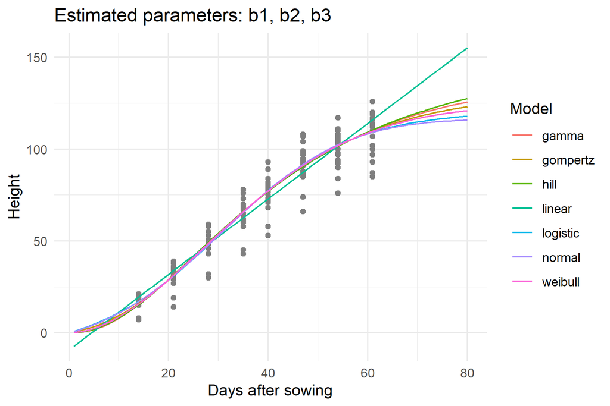

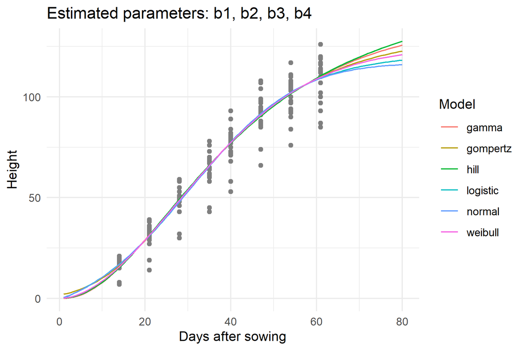

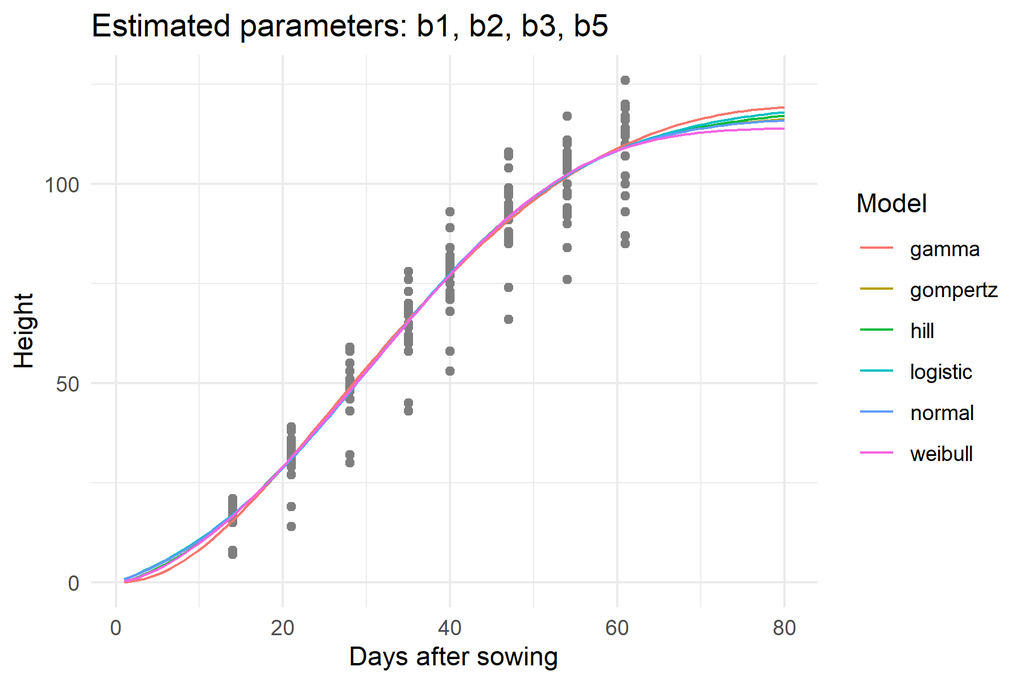

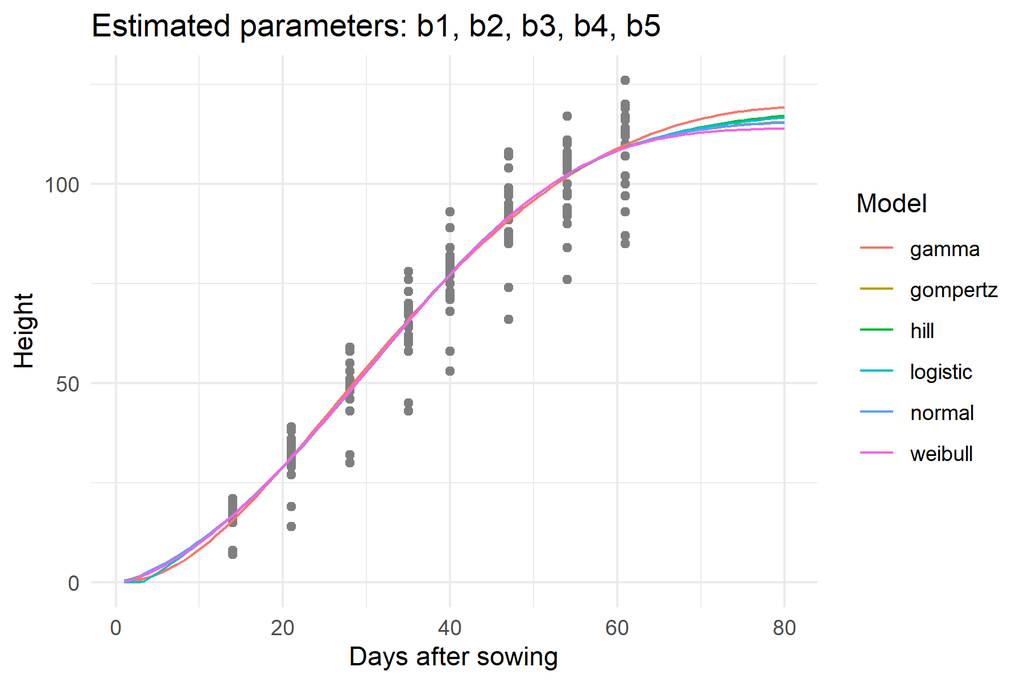

```r
ndm <- data.frame(DAS = seq(1, 80, length.out = 100))
curveplot <- function(set){
  fs <- allfits[[set]]
  curves <- do.call(rbind, lapply(names(fs), function(m)
    data.frame(ndm, height = predict(fs[[m]], newdata = ndm), model = m)))
  ggplot(FabaHeights25, aes(x = DAS, y = height)) +
    geom_point(colour = "grey50") +
    geom_line(data = curves, aes(colour = model)) +
    labs(x = "Days after sowing", y = "Height", colour = "Model", title = paste("Estimated parameters:", set)) +
    theme_minimal()
}
for (set in names(sets)) print(curveplot(set))
```

The curves of the six growth models are close to each other within the observed days, and differ mostly in their extrapolation. The estimated threshold $b_4$ is only identified by observations near it, such as zero responses before the growth starts. The heights are positive at all observation times, from day 14, so the threshold of the logistic curve stays near zero, and that of the Gompertz curve moves far below zero, where the curve is no longer truncated. For the Hill, Weibull and gamma curves, which are zero up to $t = 0$ anyway, a threshold below zero has no effect at all; the optimiser may then stop with the threshold at zero and report no convergence, with the same curve as without the threshold. The asymmetry of the gamma curve is not identified on these data either: its shape grows without bound, towards the normal curve. An estimated threshold is more useful for counts with zeros before the growth starts, as for the pods below.

### Predictions

With `interval = "confidence"`, `predict()` adds standard errors and confidence intervals for the mean response by the delta method; with `interval = "prediction"`, the intervals are for a new observation.

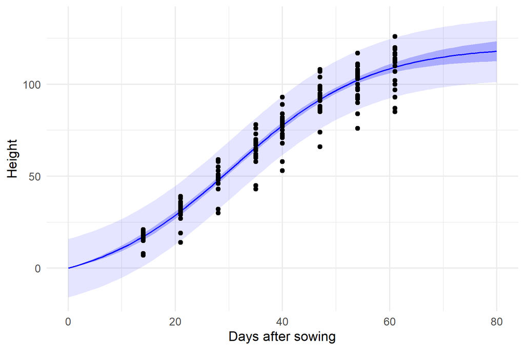

```r
nd <- data.frame(DAS = seq(0, 80, length.out = 100))
ci <- predict(fit, newdata = nd, interval = "confidence")
pi <- predict(fit, newdata = nd, interval = "prediction")
ggplot(FabaHeights25, aes(x = DAS, y = height)) +
  geom_ribbon(data = cbind(nd, pi), aes(x = DAS, ymin = lwr, ymax = upr), inherit.aes = FALSE, fill = "blue", alpha = 0.1) +
  geom_ribbon(data = cbind(nd, ci), aes(x = DAS, ymin = lwr, ymax = upr), inherit.aes = FALSE, fill = "blue", alpha = 0.25) +
  geom_line(data = cbind(nd, ci), aes(x = DAS, y = fit), colour = "blue") +
  geom_point() +
  labs(x = "Days after sowing", y = "Height") +
  theme_minimal()
```

#### Bootstrap confidence intervals

The delta method relies on the curve being close to linear in its parameters near the estimates. A parametric bootstrap avoids this: `bootstrap()` simulates new responses from the fitted model and fits the model again to each of them. Passed to `predict()` by the `boot` argument, the confidence intervals are the percentile intervals of the bootstrap curves, and `se.fit` is their standard deviation. The same bootstrap sample can be reused for the confidence intervals of the coefficients and of `timeto()`, without fitting the models again.

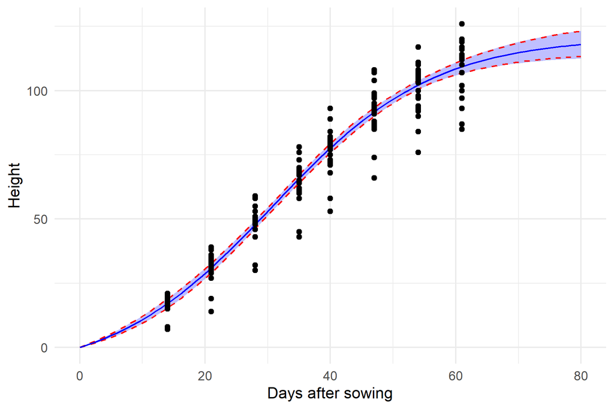

```r
bt <- bootstrap(fit, nsim = 500, seed = 1, progress = FALSE)
cib <- predict(fit, newdata = nd, interval = "confidence", boot = bt)
# delta method: shaded; bootstrap: dashed limits
ggplot(FabaHeights25, aes(x = DAS, y = height)) +
  geom_ribbon(data = cbind(nd, ci), aes(x = DAS, ymin = lwr, ymax = upr), inherit.aes = FALSE, fill = "blue", alpha = 0.25) +
  geom_line(data = cbind(nd, cib), aes(x = DAS, y = lwr), linetype = "dashed", colour = "red") +
  geom_line(data = cbind(nd, cib), aes(x = DAS, y = upr), linetype = "dashed", colour = "red") +
  geom_line(data = cbind(nd, ci), aes(x = DAS, y = fit), colour = "blue") +
  geom_point() +
  labs(x = "Days after sowing", y = "Height") +
  theme_minimal()
```

The two intervals nearly coincide here, as the curve is well determined by 200 observations. Their widths show the differences, which are largest beyond the observed days, where the curve depends on the extrapolated asymptote:

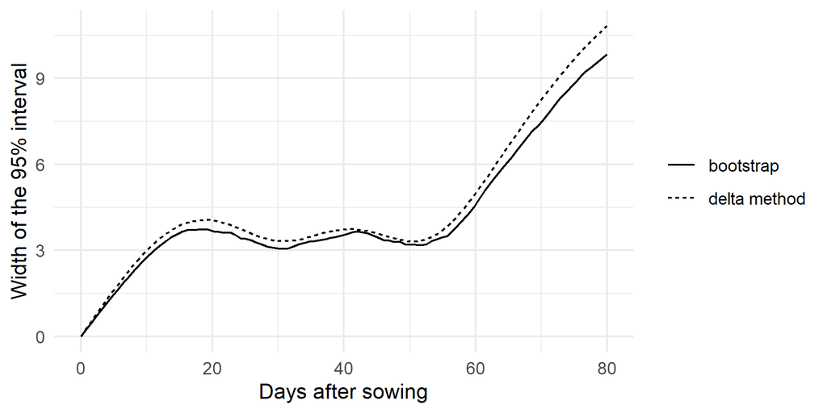

```r
widths <- rbind(data.frame(nd, width = ci$upr - ci$lwr, method = "delta method"),
                data.frame(nd, width = cib$upr - cib$lwr, method = "bootstrap"))
ggplot(widths, aes(x = DAS, y = width, linetype = method)) +
  geom_line() +
  labs(x = "Days after sowing", y = "Width of the 95% interval", linetype = NULL) +
  theme_minimal()
```

```r
confint(fit, boot = bt)
```

```
#>                     2.5 %     97.5 %
#> b1:(Intercept) 114.964246 128.191830
#> b2:(Intercept)  29.439121  32.101261
#> b3:(Intercept)  11.249579  14.907878
#> sigma            7.222271   8.758511
```

### Scale or rate

With the inverse link for $b_3$, `link = c(b3 = "inverse")`, the coefficient of $b_3$ is the rate $1/b_3$. Without covariates and random effects on $b_3$ the fit is the same; with them, covariates and random effects act additively on the rate instead of the scale.

```r
fitr <- gcTMB(height ~ DAS, data = FabaHeights25, link = c(b3 = "inverse"))
coef(fitr)
```

```
#> b1:(Intercept) b2:(Intercept) b3:(Intercept)      log_sigma
#>   120.78511756    30.72998092     0.07763509     2.07723531
```

```r
coef(fit)[["b3:(Intercept)"]]
```

```
#> [1] 12.88077
```

### Diagnostics

`plot()` draws residuals against the fitted values and against time, and a normal QQ plot. The repeated measurements of the same plants are not independent; the random effects below account for that.

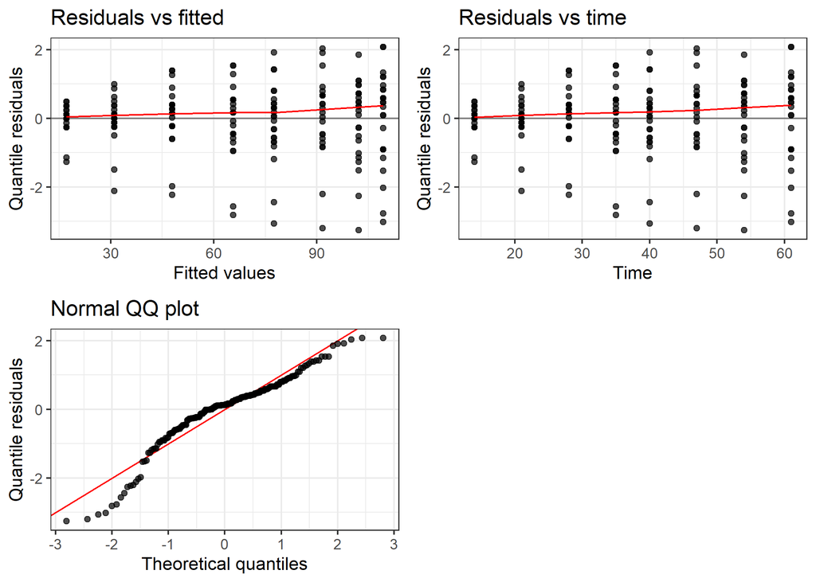

```r
plot(fit, seed = 1)
```

## Time to reach a level of the asymptote

`timeto()` gives the times at which a curve reaches a percentage of its asymptote, $b_2 + b_3 F^{-1}(p/100)$, with standard errors by automatic differentiation. With `type = "absolute"`, the times at which the curve reaches given responses, here a height of 50cm.

```r
tt <- timeto(fit, respLev = c(10, 50, 90))
tt
```

```
#> Times to reach the percentages of the asymptote:
#>
#>        Estimate Std.Error
#> 10:lf1     10.8     0.423
#> 50:lf2     32.9     0.911
#> 90:lf3     60.3     2.743
```

```r
timeto(fit, respLev = 50, type = "absolute")
```

```
#> Times to reach the responses:
#>
#>          Estimate Std.Error
#> y=50:lf1     28.8     0.336
```

`confint()` gives profile likelihood intervals by default, `method = "wald"` Wald intervals and `method = "boot"` parametric bootstrap intervals.

```r
confint(tt)
```

```
#>           2.5 %   97.5 %
#> 10:lf1 10.02726 11.69745
#> 50:lf2 31.32441 35.05932
#> 90:lf3 55.61967 66.81695
```

```r
confint(tt, method = "wald")
```

```
#>            2.5 %   97.5 %
#> 10:lf1  9.997343 11.66661
#> 50:lf2 31.109239 34.70278
#> 90:lf3 54.875711 65.69606
```

## Maximum growth rate

`maxrate()` gives the time of the maximum growth rate (`tmax`), the inflection point of the curve, the maximum growth rate there (`rate`), and the fraction of the asymptote reached at that time (`fraction`). The standard errors are by the delta method. `confint()` gives profile likelihood intervals for `tmax` and `rate` by default, and Wald intervals for `fraction`; `method = "wald"` and `method = "boot"` as for `timeto()`. For the logistic curve truncated at $b_4 = 0$, `tmax` is $b_2$, and `rate` and `fraction` follow from $b_1/(4 b_3)$ and $1/2$ as in the table of the growth models.

```r
mr <- maxrate(fit)
mr
```

```
#> Maximum growth rate (rate), its time (tmax) and the fraction of the asymptote reached then:
#>
#>              Estimate Std.Error
#> tmax:lf1       30.730   0.68220
#> rate:lf1        2.560   0.09415
#> fraction:lf1    0.454   0.00778
```

```r
confint(mr)
```

```
#>                   2.5 %     97.5 %
#> tmax:lf1     29.4384590 32.1825247
#> rate:lf1      2.3803996  2.7522120
#> fraction:lf1  0.4386425  0.4693352
```

With an estimated asymmetry, the fraction of the asymptote reached at the inflection point is estimated as well. For the Richards curve, the inflection point remains at $b_2$; for the Hill, Weibull and asymmetric Gompertz curves it differs from $b_2$.

```r
maxrate(allfits[["b1, b2, b3, b5"]]$logistic)
```

```
#> Maximum growth rate (rate), its time (tmax) and the fraction of the asymptote reached then:
#>
#>              Estimate Std.Error
#> tmax:lf1       30.666    3.0276
#> rate:lf1        2.560    0.0957
#> fraction:lf1    0.452    0.0854
```

For a truncated curve, the maximum growth rate is at the inflection point of the curve without truncation if that comes after the threshold $b_4$, and otherwise just after the threshold, where the slope jumps from zero.

## Covariates and random effects

Covariates on the parameters are given by `fform`, e.g. `b1 + b2 ~ trt` for effects of the treatment on the asymptote and the time of the maximum growth rate. Random effects are given by `rform`, e.g. `b1 + b2 ~ 1 | plant_ID` for correlated random effects of each plant on the asymptote and the time of the maximum growth rate, which account for the repeated measurements of the plants. For the heights, we use the logistic model with the defaults $b_4 = 0$ and $b_5 = 1$ fixed.

```r
FabaHeights25$trt <- factor(FabaHeights25$Treatment)
fitre <- gcTMB(height ~ DAS, fform = b1 + b2 ~ trt, rform = b1 + b2 ~ 1 | plant_ID, data = FabaHeights25)
summary(fitre)
```

```
#> Call:
#> gcTMB(form = height ~ DAS, fform = b1 + b2 ~ trt, rform = b1 +
#>     b2 ~ 1 | plant_ID, data = FabaHeights25)
#>
#> Model:  logistic, increasing curve, truncated at b4 = 0
#> Family: gaussian, identity link for all parameters
#>
#> Number of observations: 200, groups: plant_ID 25
#> Log-likelihood: -508.2 (df = 15), AIC: 1046, BIC: 1096
#>
#> Coefficients:
#>                Estimate Std. Error
#> b1:(Intercept) 115.7637      4.144
#> b1:trt0.3       -1.9226      5.743
#> b1:trt0.5        9.7398      5.754
#> b1:trt0.6       10.6189      5.758
#> b1:trt0.8        8.2848      5.759
#> b2:(Intercept)  30.8173      1.141
#> b2:trt0.3       -1.4951      1.610
#> b2:trt0.5        0.1777      1.605
#> b2:trt0.6        0.6744      1.605
#> b2:trt0.8        0.9027      1.606
#> b3:(Intercept)  12.8471      0.250
#>
#> Random effects:
#>  Groups   Name Std.Dev. Corr
#>  plant_ID b1   8.834
#>           b2   2.395    -0.32
#>
#> Residual standard deviation: 2.076
#>
#> Optimiser: relative convergence (4), maximum absolute gradient 3.7e-05
```

Likelihood ratio tests by `anova()` compare nested models, here with and without the treatment effects.

```r
fitre0 <- gcTMB(height ~ DAS, rform = b1 + b2 ~ 1 | plant_ID, data = FabaHeights25)
anova(fitre0, fitre)
```

```
#> Likelihood ratio tests of gcTMB models
#>
#>        npar    AIC    BIC  logLik deviance  Chisq Df Pr(>Chisq)
#> fitre0    7 1041.3 1064.4 -513.67   1027.3
#> fitre    15 1046.3 1095.8 -508.17   1016.3 11.006  8     0.2014
```

`predict()` gives the curves of the fitted plants with their predicted random effects (`random = TRUE`), or the population curves of the treatments (`random = FALSE`); `timeto()` with `newdata` gives the times of the curves of each row.

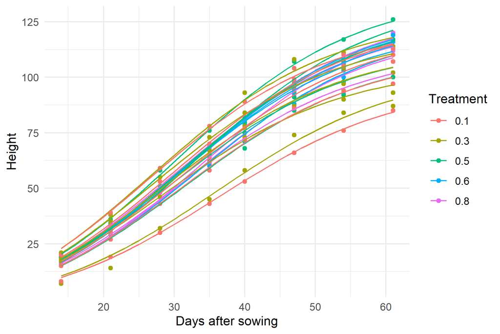

```r
nd <- unique(FabaHeights25[, c("plant_ID", "trt")])
nd <- merge(nd, data.frame(DAS = seq(14, 61, 1)))
nd$fit <- predict(fitre, newdata = nd)
ggplot(FabaHeights25, aes(x = DAS, y = height, colour = trt)) +
  geom_point() +
  geom_line(data = nd, aes(y = fit, group = plant_ID)) +
  labs(x = "Days after sowing", y = "Height", colour = "Treatment") +
  theme_minimal()
```

```r
timeto(fitre, respLev = 90, newdata = data.frame(trt = levels(FabaHeights25$trt)), random = FALSE)
```

```
#> Times to reach the percentages of the asymptote:
#>
#>            Estimate Std.Error
#> 90:trt=0.1     60.3      1.24
#> 90:trt=0.3     58.9      1.21
#> 90:trt=0.5     60.4      1.24
#> 90:trt=0.6     60.9      1.25
#> 90:trt=0.8     61.1      1.25
```

## Non-normal responses

The `family` argument gives the distribution of the response: “gaussian”, “lognormal”, “poisson”, “nbinom2”, “nbinom1”, “binomial”, “betabinomial” or “beta”. The data set `FabaCounts23` contains the numbers of pods of 22 faba bean plants of six genotypes, counted between 61 and 79 days after sowing. The plants have no pods at the first counts, so the threshold $b_4$, the time of the first pods, is identified by the zero counts and estimated; the asymmetry is fixed at $b_5 = 1$. A Poisson model with an asymptote and a time of the maximum growth rate for each genotype, and a random asymptote for each plant:

```r
fitp <- gcTMB(pods ~ DAS, fform = b1 + b2 ~ Genotype, rform = b1 ~ 1 | Tube_ID, data = FabaCounts23,
              family = "poisson", fix = c(b4 = FALSE))
summary(fitp)
```

```
#> Call:
#> gcTMB(form = pods ~ DAS, fform = b1 + b2 ~ Genotype, rform = b1 ~
#>     1 | Tube_ID, data = FabaCounts23, fix = c(b4 = FALSE), family = "poisson")
#>
#> Model:  logistic, increasing curve, truncated at the threshold b4
#> Family: poisson, identity link for all parameters
#>
#> Number of observations: 263, groups: Tube_ID 22
#> Log-likelihood: -353.6 (df = 15), AIC: 737.1, BIC: 790.7
#>
#> Coefficients:
#>                    Estimate Std. Error
#> b1:(Intercept)      14.5996      2.324
#> b1:GenotypeCapri    -3.4020      2.974
#> b1:GenotypeILB938   -5.4787      2.957
#> b1:GenotypeLynx      4.9819      3.233
#> b1:GenotypeMelodie  10.6976      3.676
#> b1:GenotypeNavara    3.1797      3.186
#> b2:(Intercept)      70.0533      0.469
#> b2:GenotypeCapri    -0.8504      0.640
#> b2:GenotypeILB938   -1.0084      0.702
#> b2:GenotypeLynx      2.7439      0.551
#> b2:GenotypeMelodie   3.2443      0.552
#> b2:GenotypeNavara    2.6005      0.558
#> b3:(Intercept)       1.3389      0.149
#> b4:(Intercept)      65.0000      0.024
#>
#> Random effects:
#>  Groups  Name Std.Dev.
#>  Tube_ID b1   3.355
#>
#> Pearson dispersion: 0.5005 (chi-square 124.1 on 248 df)
#>
#> Optimiser: converged, with the threshold b4 at an observation time (a kink of the likelihood), maximum absolute gradient 0.27
```

```r
genotypes <- data.frame(Genotype = sort(unique(FabaCounts23$Genotype)))
predict(fitp, newdata = genotypes, type = "parameters", random = FALSE)
```

```
#>             b1       b2       b3 b4
#> [1,] 14.599634 70.05332 1.338935 65
#> [2,] 11.197618 69.20292 1.338935 65
#> [3,]  9.120981 69.04494 1.338935 65
#> [4,] 19.581583 72.79718 1.338935 65
#> [5,] 25.297268 73.29758 1.338935 65
#> [6,] 17.779358 72.65387 1.338935 65
```

All the counts with the fitted curve of each plant, with its predicted random asymptote:

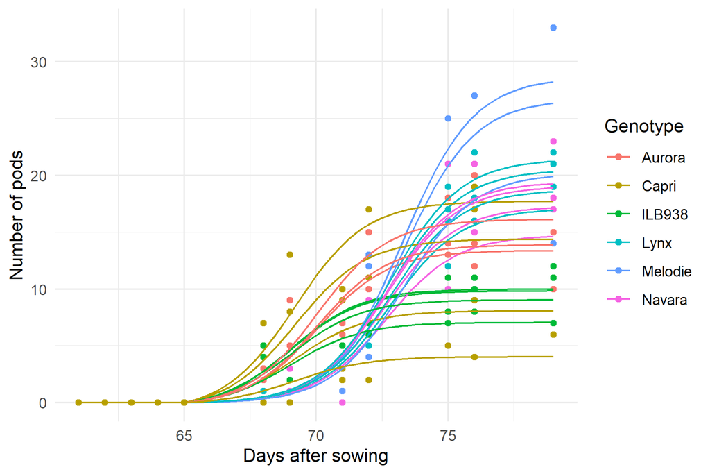

```r
days <- seq(61, 79, 0.25)
ndp <- merge(unique(FabaCounts23[, c("Tube_ID", "Genotype")]), data.frame(DAS = days))
ndp$fit <- predict(fitp, newdata = ndp)
ggplot(FabaCounts23, aes(x = DAS, y = pods, colour = Genotype)) +
  geom_point() +
  geom_line(data = ndp, aes(y = fit, group = Tube_ID)) +
  labs(x = "Days after sowing", y = "Number of pods", colour = "Genotype") +
  theme_minimal()
```

By genotype, the curves of the plants together with the population curves of the genotypes (`random = FALSE`), the fixed effects, with 95% confidence intervals. For Poisson models, the confidence intervals of the mean are computed on the log scale, so that they stay positive.

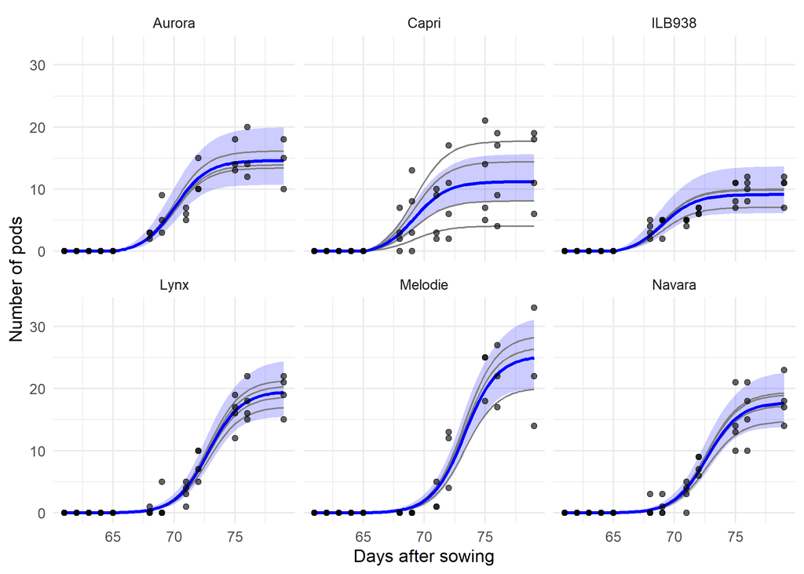

```r
# the population curve of each genotype
ndg <- merge(genotypes, data.frame(DAS = days))
ndg <- cbind(ndg, predict(fitp, newdata = ndg, random = FALSE, interval = "confidence"))
ggplot(FabaCounts23, aes(x = DAS, y = pods)) +
  geom_ribbon(data = ndg, aes(x = DAS, ymin = lwr, ymax = upr), inherit.aes = FALSE, fill = "blue", alpha = 0.2) +
  geom_line(data = ndp, aes(y = fit, group = Tube_ID), colour = "grey50") +
  geom_line(data = ndg, aes(y = fit), colour = "blue", linewidth = 1) +
  geom_point(alpha = 0.6) +
  facet_wrap(~ Genotype) +
  labs(x = "Days after sowing", y = "Number of pods") +
  theme_minimal()
```

The estimated threshold improves the fit over the default threshold at sowing:

```r
fitp0 <- gcTMB(pods ~ DAS, fform = b1 + b2 ~ Genotype, rform = b1 ~ 1 | Tube_ID, data = FabaCounts23,
               family = "poisson")
AIC(fitp0, fitp)
```

```
#>       df      AIC
#> fitp0 14 745.3067
#> fitp  15 737.1423
```